# Reproducible Research: Activity monitoring

- **Loading and preprocessing the data**

```r
setwd("C:\\Users\\ladym\\Downloads")
unzip("repdata_data_activity.zip")
data_file <- "activity.csv"
activity <- read.csv(data_file, header = TRUE, stringsAsFactors = FALSE)
activity$date <- as.Date(activity$date) # Convert date to Date class

str(activity)
```

```
## 'data.frame':    17568 obs. of  3 variables:
##  $ steps   : int  NA NA NA NA NA NA NA NA NA NA ...
##  $ date    : Date, format: "2012-10-01" "2012-10-01" ...
##  $ interval: int  0 5 10 15 20 25 30 35 40 45 ...
```

```r
head(activity)
```

```
##   steps       date interval
## 1    NA 2012-10-01        0
## 2    NA 2012-10-01        5
## 3    NA 2012-10-01       10
## 4    NA 2012-10-01       15
## 5    NA 2012-10-01       20
## 6    NA 2012-10-01       25
```

## What is the mean total number of steps taken per day?

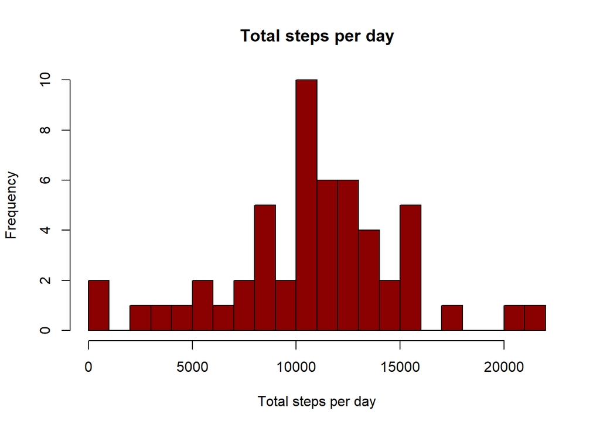

```r
# Total steps per day (ignoring NA)
total_steps_per_day <- activity %>%
  filter(!is.na(steps)) %>%
  group_by(date) %>%
  summarize(total_steps = sum(steps))

# Histogram of total steps per day
hist(total_steps_per_day$total_steps,
     main = "Total steps per day",
     xlab = "Total steps per day",
     col= "darkred",
     breaks = 25)
```

```r
mean_total <- mean(total_steps_per_day$total_steps)
median_total <- median(total_steps_per_day$total_steps)

cat("Mean =", mean_total,"\nMedian =",median_total)
```

```
## Mean = 10766.19
## Median = 10765
```

**Answer:** The mean and median values printed are the mean and median total number of steps taken per day ignoring the missing values (NA)

## What is the average daily activity pattern?

Make a time series plot of the 5-minute interval (x-axis) and the average number of steps taken, averaged across all days (y-axis).

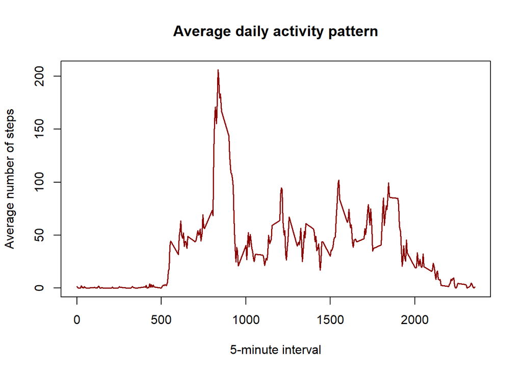

```r
interval_avg <- activity %>%
  group_by(interval) %>%
  summarize(avg_steps = mean(steps, na.rm = TRUE))

# Time series plot
plot(interval_avg$interval, interval_avg$avg_steps, type = "l",
     xlab = "5-minute interval", ylab = "Average number of steps",
     col="darkred" ,
     lwd = 1.5,
     main = "Average daily activity pattern")
```

- Which 5-minute interval, on average across all the days in the dataset, contains the maximum number of steps?

```r
max_row <- interval_avg[which.max(interval_avg$avg_steps), ] #maximum average steps
max_row
```

```
## # A tibble: 1 × 2
##   interval avg_steps
##      <int>     <dbl>
## 1      835      206.
```

**Answer:** The interval printed above contains the maximum average number of steps.

## Imputing missing values

```r
total_missing <- sum(is.na(activity$steps))
cat("Total number of missing values in the dataset =", total_missing)
```

```
## Total number of missing values in the dataset = 2304
```

There are 2304 missing values in the dataset.

*Strategy for filling in the missing values:* Impute missing `steps` values by using the mean number of steps for that 5-minute interval calculated across all days (i.e., use the interval average) preserving the typical pattern for that interval while being simple and reproducible.

```r
# Create a named vector of interval means
interval_mean_vec <- setNames(interval_avg$avg_steps, interval_avg$interval)

# Make a copy of the dataset and replace NAs with interval mean vector
activity_filled <- activity
na_idx <- which(is.na(activity_filled$steps))
activity_filled$steps[na_idx] <- interval_mean_vec[as.character(activity_filled$interval[na_idx])]

cat("NAs total values =",sum(is.na(activity_filled$steps))) #Verify no NAs remain
```

```
## NAs total values = 0
```

Now compute total steps per day with imputed data and plot the new histogram

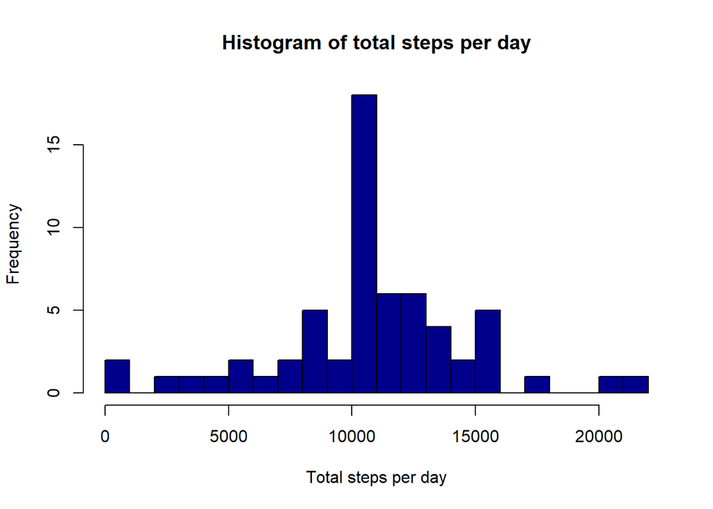

```r
total_steps_per_day_filled <- activity_filled %>%
  group_by(date) %>%
  summarize(total_steps = sum(steps))

# Histogram
hist(total_steps_per_day_filled$total_steps,
     main = "Histogram of total steps per day",
     xlab = "Total steps per day",
     col = "blue4",
     breaks = 25)
```

```r
mean_total_filled <- mean(total_steps_per_day_filled$total_steps)
median_total_filled <- median(total_steps_per_day_filled$total_steps)

cat("New mean =", mean_total_filled,"   Mean =", mean_total)
```

```
## New mean = 10766.19    Mean = 10766.19
```

```r
cat("\nNew median =",median_total_filled," Median =",median_total)
```

```
##
## New median = 10766.19  Median = 10765
```

## Are there differences in activity patterns between weekdays and weekends?

Create a factor variable with the levels “weekday” and “weekend” using the imputed dataset for this analysis.

```r
activity_filled$dayType <- ifelse(as.POSIXlt(activity_filled$date)$wday %in% c(0, 6), #0=Sunday,6=Saturday
                                  "weekend", "weekday")

activity_filled$dayType <- factor(activity_filled$dayType,
                                  levels = c("weekday", "weekend"))

# Average by interval and dayType
interval_daytype_avg <- activity_filled %>%
  group_by(interval, dayType) %>%
  summarize(avg_steps = mean(steps))

head(interval_daytype_avg)
```

```
## # A tibble: 6 × 3
## # Groups:   interval [3]
##   interval dayType avg_steps
##      <int> <fct>       <dbl>
## 1        0 weekday    2.25
## 2        0 weekend    0.215
## 3        5 weekday    0.445
## 4        5 weekend    0.0425
## 5       10 weekday    0.173
## 6       10 weekend    0.0165
```

Panel plot with time series comparing weekdays and weekends.

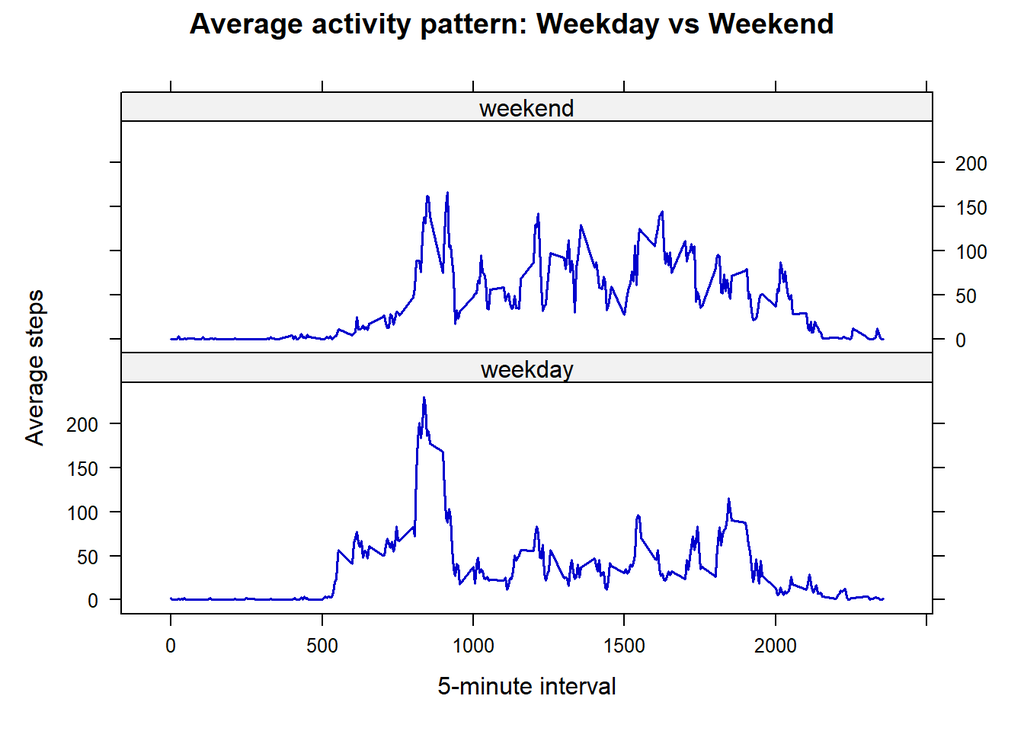

```r
# Using lattice for a split panel plot
xyplot(avg_steps ~ interval | dayType, data = interval_daytype_avg, type = "l",
       layout = c(1,2),
       xlab = "5-minute interval", ylab = "Average steps",
       col.line = c("blue3"),
       lwd = 1.5,
       main = "Average activity pattern: Weekday vs Weekend")
```